# HW5_Decomposition_Hung Jui Chao

Hung Jui Chao

2026-10-07

# Decomposition

## Install Package

```r
library(readxl)
library(forecast)
```

## Read Excel

```r
NJ <- read_excel("NJ_Unemployment_Rate_5Y.xlsx",
                 sheet = "NJ Unemployment Data")

head(NJ)
```

```
## # A tibble: 6 × 2
##   Date                NJ_Unemployment_Rate
##   <dttm>                             <dbl>
## 1 2020-09-01 00:00:00                  7.4
## 2 2020-10-01 00:00:00                  7.1
## 3 2020-11-01 00:00:00                  7.2
## 4 2020-12-01 00:00:00                  7.3
## 5 2021-01-01 00:00:00                  7.4
## 6 2021-02-01 00:00:00                  7.4
```

## Create monthly time series Data

```r
NJ_ts <- ts(NJ$NJ_Unemployment_Rate, start = c(2020,9), frequency = 12)
NJ_ts
```

```
##      Jan Feb Mar Apr May Jun Jul Aug Sep Oct Nov Dec
## 2020                                 7.4 7.1 7.2 7.3
## 2021 7.4 7.4 7.3 7.3 7.0 7.2 6.9 6.7 6.2 5.9 5.6 5.5
## 2022 5.2 4.7 4.3 4.1 3.8 3.6 3.3 3.1 3.3 3.5 3.7 3.8
## 2023 3.9 4.0 4.1 4.2 4.2 4.3 4.4 4.5 4.5 4.5 4.5 4.5
## 2024 4.5 4.5 4.5 4.6 4.6 4.6 4.7 4.7 4.7 4.7 4.8 4.8
## 2025 4.9 5.0 5.1 5.1 5.2 5.4 5.5 5.5
```

## Plot Time series

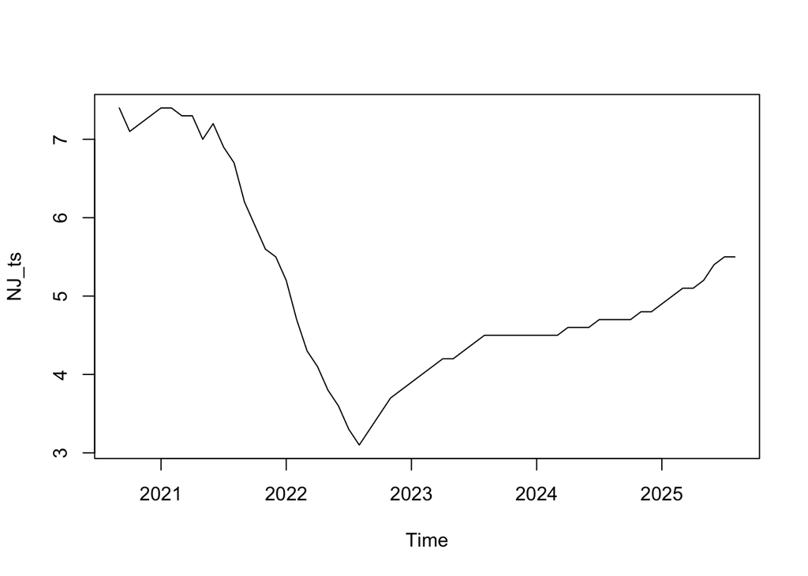

```r
plot(NJ_ts)
```

## Use Stl and Plot

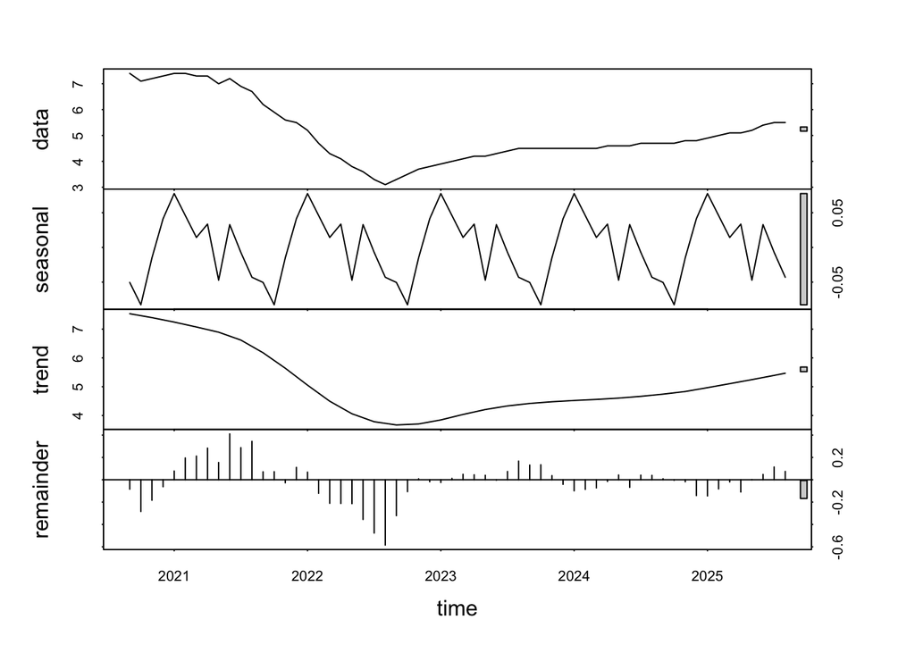

```r
stl_decomp_NJ <- stl(NJ_ts,s.window ="periodic")
plot(stl_decomp_NJ)
```

### Explain: The STL decomposition shows a clear trend in NJ unemployment rate. The unemployment rate decreased from 2021 to around 2022-2023 and then gradually increased afterward. A recurring seasonality pattern is also presented but its magnitutude is relatively small compared to overall trend which only range from -0.05 to 0.05. The remainder fluctuates around zero, representing irregular variations that cannot be explained by the trend and seasonality.

## See the attribute

```r
attributes(stl_decomp_NJ)
```

```
## $names
## [1] "time.series" "weights"     "call"        "win"         "deg"
## [6] "jump"        "inner"       "outer"
##
## $class
## [1] "stl"
```

## Do the seasonal adjustment

```r
seas_stl_decomp_NJ <- seasadj(stl_decomp_NJ) ## remove seasonal effect
seas_stl_decomp_NJ
```

```
##           Jan      Feb      Mar      Apr      May      Jun      Jul      Aug
## 2020
## 2021 7.322412 7.354040 7.285667 7.266427 7.047187 7.167178 6.907169 6.743030
## 2022 5.122412 4.654040 4.285667 4.066427 3.847187 3.567178 3.307169 3.143030
## 2023 3.822412 3.954040 4.085667 4.166427 4.247187 4.267178 4.407169 4.543030
## 2024 4.422412 4.454040 4.485667 4.566427 4.647187 4.567178 4.707169 4.743030
## 2025 4.822412 4.954040 5.085667 5.066427 5.247187 5.367178 5.507169 5.543030
##           Sep      Oct      Nov      Dec
## 2020 7.450476 7.182731 7.214986 7.258699
## 2021 6.250476 5.982731 5.614986 5.458699
## 2022 3.350476 3.582731 3.714986 3.758699
## 2023 4.550476 4.582731 4.514986 4.458699
## 2024 4.750476 4.782731 4.814986 4.758699
## 2025
```

## Plot

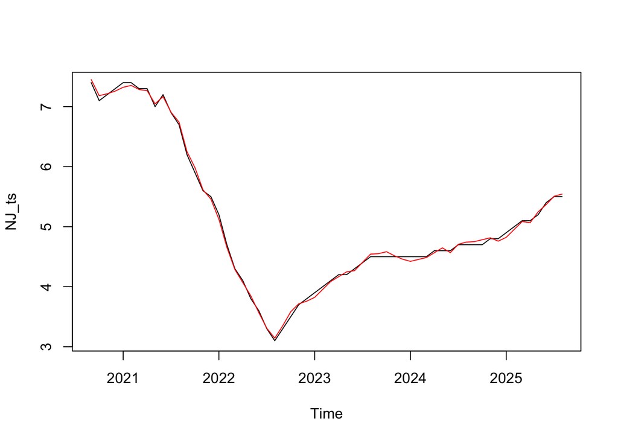

```r
plot(NJ_ts)
lines(seas_stl_decomp_NJ, col = "red")
```

### Explain: We can tell from the chart that seasonal effect to the NJ unemployment rate is relatively small since the line of NJ unemployment rate without seasonal effect is almost matched to the orginal data. This also show in the graph of stl_decomp_NJ that seasonality is relatively small compared to the overall trend which only range from -0.05 to 0.05.

## Do the forecast for next year NJ unemployment rate

```r
fc_stl_NJ <- forecast(stl_decomp_NJ, h = 12)
fc_stl_NJ
```

```
##          Point Forecast    Lo 80    Hi 80    Lo 95    Hi 95
## Sep 2025       5.544716 5.384464 5.704967 5.299632 5.789799
## Oct 2025       5.547049 5.256119 5.837980 5.102109 5.991989
## Nov 2025       5.642465 5.205922 6.079008 4.974830 6.310100
## Dec 2025       5.720889 5.134450 6.307328 4.824007 6.617770
## Jan 2026       5.774885 5.039034 6.510737 4.649497 6.900273
## Feb 2026       5.757425 4.875125 6.639725 4.408063 7.106787
## Mar 2026       5.737131 4.712663 6.761600 4.170342 7.303921
## Apr 2026       5.765439 4.603736 6.927142 3.988768 7.542110
## May 2026       5.691933 4.398188 6.985678 3.713321 7.670545
## Jun 2026       5.777745 4.357168 7.198321 3.605161 7.950329
## Jul 2026       5.742396 4.200072 7.284720 3.383615 8.101177
## Aug 2026       5.710249 4.051052 7.369447 3.172725 8.247774
```

## Plot the forecast

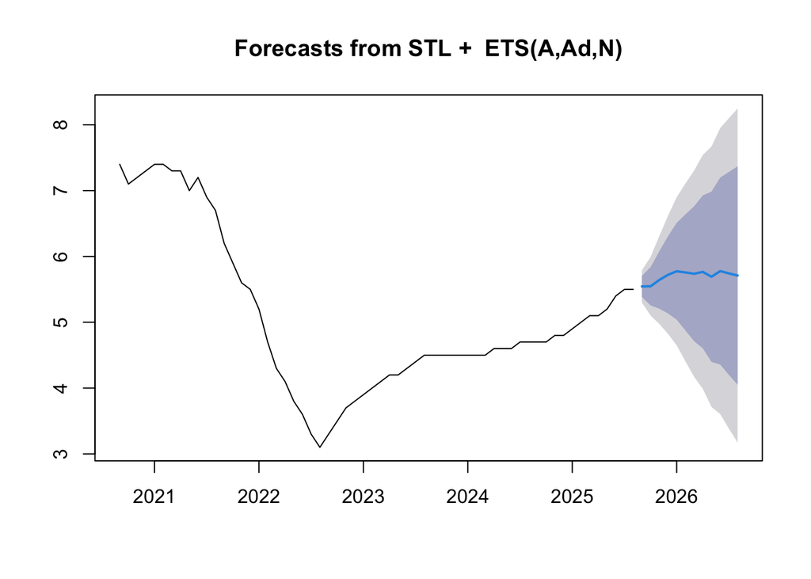

```r
plot(fc_stl_NJ)
```

### Explain: ETS(A,Ad,N) forecasts the future one year series using an additive error and damped trend. A means additive Error, Ad means Additive Dampend Trend, and N means No Seansonality in the ETS component.

## Use other option to do the decomposition: decompose()

```r
decomp_NJ <- decompose(NJ_ts)
decomp_NJ
```

```
## $x
##      Jan Feb Mar Apr May Jun Jul Aug Sep Oct Nov Dec
## 2020                                 7.4 7.1 7.2 7.3
## 2021 7.4 7.4 7.3 7.3 7.0 7.2 6.9 6.7 6.2 5.9 5.6 5.5
## 2022 5.2 4.7 4.3 4.1 3.8 3.6 3.3 3.1 3.3 3.5 3.7 3.8
## 2023 3.9 4.0 4.1 4.2 4.2 4.3 4.4 4.5 4.5 4.5 4.5 4.5
## 2024 4.5 4.5 4.5 4.6 4.6 4.6 4.7 4.7 4.7 4.7 4.8 4.8
## 2025 4.9 5.0 5.1 5.1 5.2 5.4 5.5 5.5
##
## $seasonal
##                Jan           Feb           Mar           Apr           May
## 2020
## 2021  0.0462673611 -0.0016493056  0.0077256944  0.0608506944 -0.0391493056
## 2022  0.0462673611 -0.0016493056  0.0077256944  0.0608506944 -0.0391493056
## 2023  0.0462673611 -0.0016493056  0.0077256944  0.0608506944 -0.0391493056
## 2024  0.0462673611 -0.0016493056  0.0077256944  0.0608506944 -0.0391493056
## 2025  0.0462673611 -0.0016493056  0.0077256944  0.0608506944 -0.0391493056
##                Jun           Jul           Aug           Sep           Oct
## 2020                                           -0.0620659722 -0.0412326389
## 2021  0.0368923611 -0.0110243056 -0.0349826389 -0.0620659722 -0.0412326389
## 2022  0.0368923611 -0.0110243056 -0.0349826389 -0.0620659722 -0.0412326389
## 2023  0.0368923611 -0.0110243056 -0.0349826389 -0.0620659722 -0.0412326389
## 2024  0.0368923611 -0.0110243056 -0.0349826389 -0.0620659722 -0.0412326389
## 2025  0.0368923611 -0.0110243056 -0.0349826389
##                Nov           Dec
## 2020  0.0004340278  0.0379340278
## 2021  0.0004340278  0.0379340278
## 2022  0.0004340278  0.0379340278
## 2023  0.0004340278  0.0379340278
## 2024  0.0004340278  0.0379340278
## 2025
##
## $trend
##           Jan      Feb      Mar      Apr      May      Jun      Jul      Aug
## 2020
## 2021       NA       NA 7.133333 7.033333 6.916667 6.775000 6.608333 6.404167
## 2022 5.058333 4.758333 4.487500 4.266667 4.087500 3.937500 3.812500 3.729167
## 2023 3.829167 3.933333 4.041667 4.133333 4.208333 4.270833 4.325000 4.370833
## 2024 4.529167 4.550000 4.566667 4.583333 4.604167 4.629167 4.658333 4.695833
## 2025 4.958333 5.025000       NA       NA       NA       NA       NA       NA
```

[output cut: 26 more lines]

```
## 2022 -0.008767361  0.007899306
## 2023  0.024565972 -0.042100694
## 2024 -0.033767361 -0.129600694
## 2025
##
## $figure
##  [1] -0.0620659722 -0.0412326389  0.0004340278  0.0379340278  0.0462673611
##  [6] -0.0016493056  0.0077256944  0.0608506944 -0.0391493056  0.0368923611
## [11] -0.0110243056 -0.0349826389
##
## $type
## [1] "additive"
##
## attr(,"class")
## [1] "decomposed.ts"
```

## See the attributes

```r
attributes(decomp_NJ)
```

```
## $names
## [1] "x"        "seasonal" "trend"    "random"   "figure"   "type"
##
## $class
## [1] "decomposed.ts"
```

## Remove Seasonal from decomp_NJ

```r
seasadj_decomp_NJ = seasadj(decomp_NJ)
seasadj_decomp_NJ
```

```
##           Jan      Feb      Mar      Apr      May      Jun      Jul      Aug
## 2020
## 2021 7.353733 7.401649 7.292274 7.239149 7.039149 7.163108 6.911024 6.734983
## 2022 5.153733 4.701649 4.292274 4.039149 3.839149 3.563108 3.311024 3.134983
## 2023 3.853733 4.001649 4.092274 4.139149 4.239149 4.263108 4.411024 4.534983
## 2024 4.453733 4.501649 4.492274 4.539149 4.639149 4.563108 4.711024 4.734983
## 2025 4.853733 5.001649 5.092274 5.039149 5.239149 5.363108 5.511024 5.534983
##           Sep      Oct      Nov      Dec
## 2020 7.462066 7.141233 7.199566 7.262066
## 2021 6.262066 5.941233 5.599566 5.462066
## 2022 3.362066 3.541233 3.699566 3.762066
## 2023 4.562066 4.541233 4.499566 4.462066
## 2024 4.762066 4.741233 4.799566 4.762066
## 2025
```

## Plot

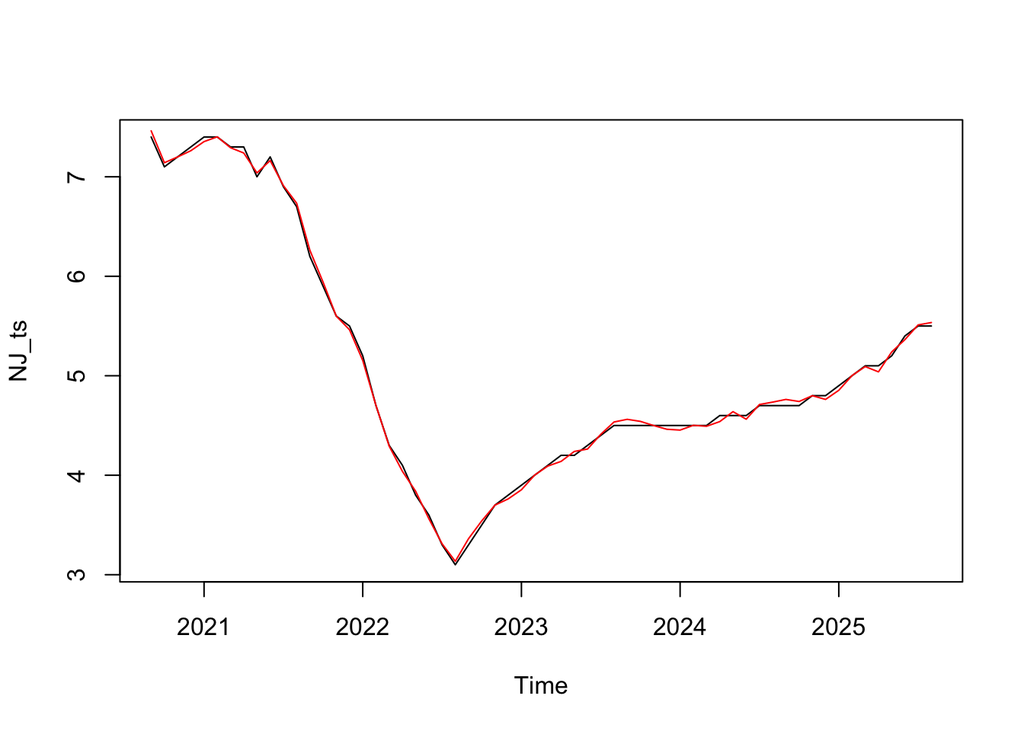

```r
plot(NJ_ts)
lines(seasadj_decomp_NJ, col = "red")
```

### Explain: same as previous show that seasonality do small in the data so there is no significant effect when we remove the seasonal effect.

## Do the forecast for data remove seasonal effect

```r
fc_seas_NJ = forecast(seasadj_decomp_NJ, h = 12) ## forecast next year without seasonal effect
fc_seas_NJ
```

```
##          Point Forecast    Lo 80    Hi 80    Lo 95    Hi 95
## Sep 2025       5.581054 5.416695 5.745414 5.329689 5.832420
## Oct 2025       5.612674 5.314850 5.910498 5.157192 6.068157
## Nov 2025       5.637970 5.196487 6.079454 4.962779 6.313162
## Dec 2025       5.658207 5.070507 6.245908 4.759397 6.557018
## Jan 2026       5.674397 4.941706 6.407087 4.553843 6.794950
## Feb 2026       5.687348 4.812939 6.561758 4.350054 7.024643
## Mar 2026       5.697710 4.685944 6.709475 4.150348 7.245072
## Apr 2026       5.705999 4.561772 6.850225 3.956055 7.455943
## May 2026       5.712630 4.441026 6.984234 3.767880 7.657380
## Jun 2026       5.717935 4.324019 7.111851 3.586125 7.849745
## Jul 2026       5.722179 4.210872 7.233486 3.410834 8.033524
## Aug 2026       5.725574 4.101579 7.349569 3.241887 8.209261
```

## Plot the forecast

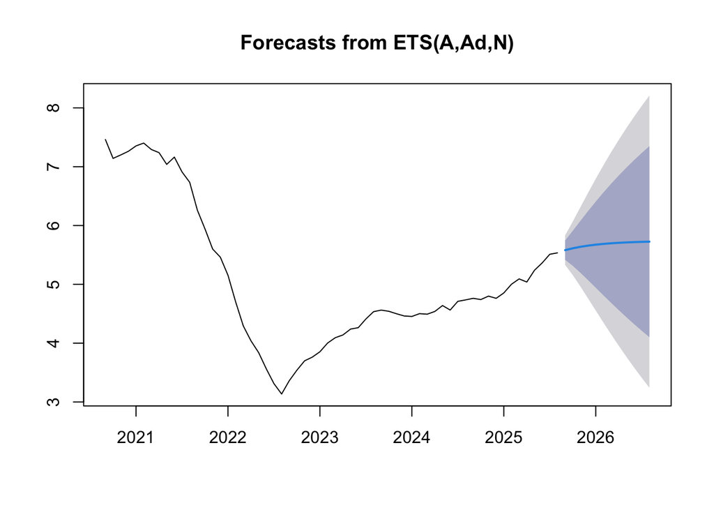

```r
plot(fc_seas_NJ)
```

### Explain: We can see from the chart that the forecast is relatively smooth compared to previous chart since we have remove the seasonal effect from the data.

## Plot the decomp_NJ and its forecast

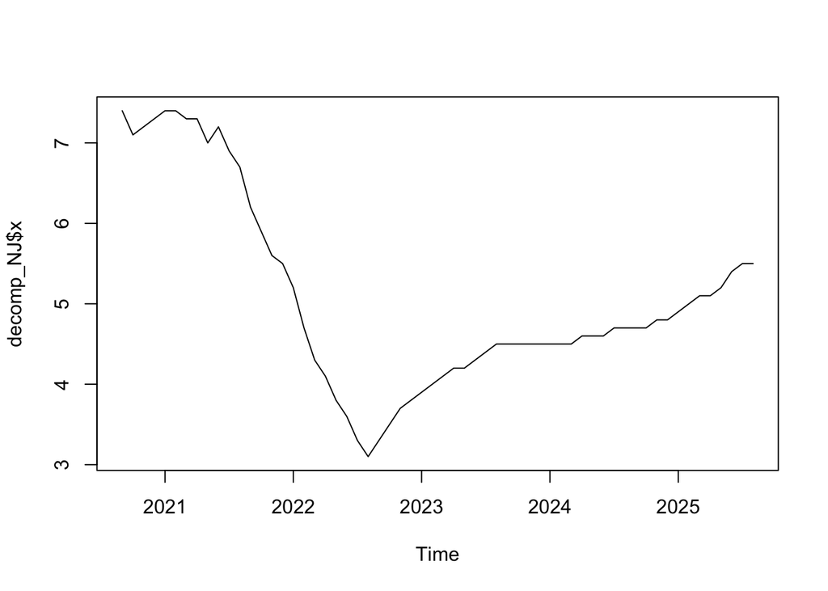

```r
plot(decomp_NJ$x)
```

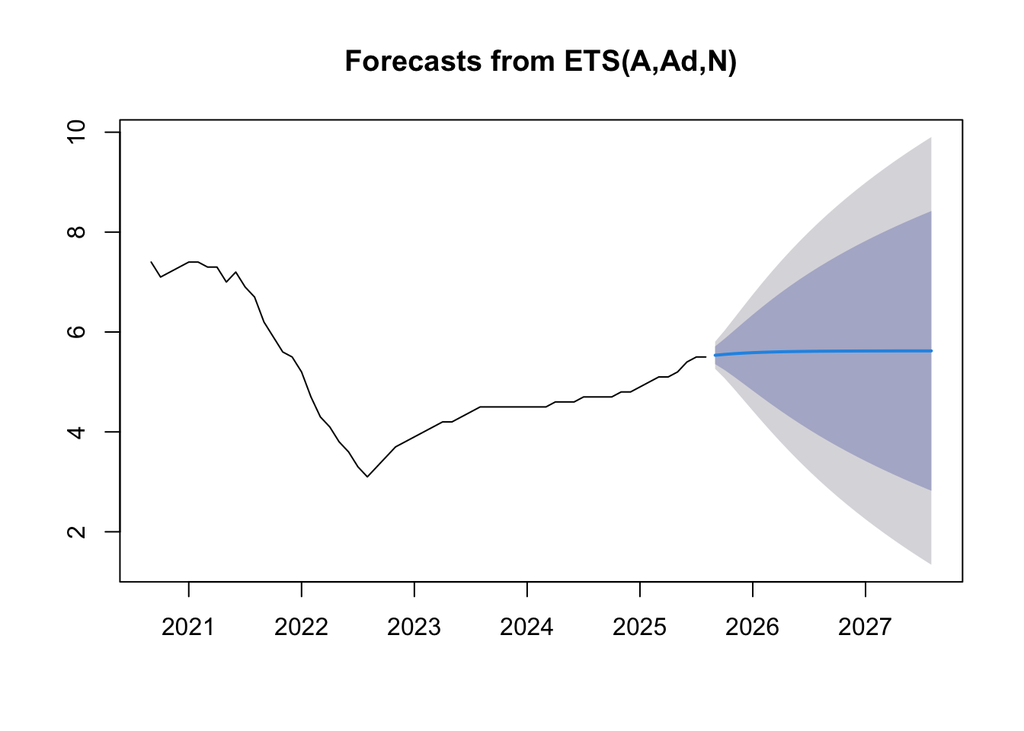

```r
plot(forecast(decomp_NJ$x))
```

## See the accuracy with other model

```r
accuracy(fc_seas_NJ)
```

```
##                        ME      RMSE       MAE        MPE     MAPE       MASE
## Training set -0.001412008 0.1227902 0.0906283 0.04593622 1.809534 0.07436168
##                      ACF1
## Training set -0.001390668
```

```r
HW_NJ = HoltWinters((NJ_ts))
accuracy(forecast(HW_NJ))
```

```
##                      ME      RMSE       MAE       MPE     MAPE     MASE
## Training set 0.02031734 0.2545643 0.1716999 0.7834687 3.945085 0.140882
##                  ACF1
## Training set 0.033303
```

```r
ETS_NJ = ets(NJ_ts)
accuracy(forecast(ETS_NJ))
```

```
##                        ME      RMSE        MAE       MPE     MAPE       MASE
## Training set -0.003198643 0.1328658 0.09178555 0.0218789 1.798708 0.07531122
##                     ACF1
## Training set -0.01752757
```

### Explain: We can tell from the RMSE numbers that the forecast of removing seasonal effect from data is the best fitted model since the number is the lowest.